First things, first: let's load the data into a dataframe (df).

```r
df <- read.csv("activity.csv")
```

Next, we'll check to make sure the dimensions are what we expect (17568 x 3):

```r
dim(df)
```

```
## [1] 17568     3
```

And double-check the column/variable heading:

```r
names(df)
```

```
## [1] "steps"    "date"     "interval"
```

And glance at the “head” of the dataset:

```r
head(df)
```

```
##   steps       date interval
## 1    NA 2012-10-01        0
## 2    NA 2012-10-01        5
## 3    NA 2012-10-01       10
## 4    NA 2012-10-01       15
## 5    NA 2012-10-01       20
## 6    NA 2012-10-01       25
```

All looks well. Now, let's do some analysis.

First, we want to calculate the Total (i.e. sum) number of steps taken each day (TPD = TotalperDay).

```r
TPD <- aggregate(. ~ date, data =df, sum)
TPD
```

```
##          date steps interval
## 1  2012-10-02   126   339120
## 2  2012-10-03 11352   339120
## 3  2012-10-04 12116   339120
## 4  2012-10-05 13294   339120
## 5  2012-10-06 15420   339120
## 6  2012-10-07 11015   339120
## 7  2012-10-09 12811   339120
## 8  2012-10-10  9900   339120
## 9  2012-10-11 10304   339120
## 10 2012-10-12 17382   339120
## 11 2012-10-13 12426   339120
## 12 2012-10-14 15098   339120
## 13 2012-10-15 10139   339120
## 14 2012-10-16 15084   339120
```

[output cut: 39 more lines]

Visual learners, like myself, will prefer to see that data as a histogram:

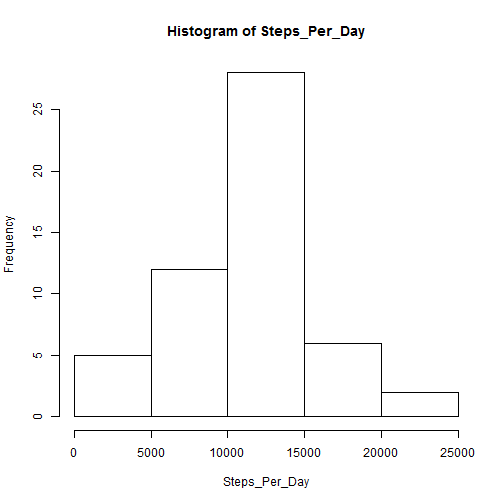

```r
Steps_Per_Day <- TPD$steps
hist(Steps_Per_Day)
```

Next, let's compute two simple summary statistics: mean and median.

```r
steps_mean <- mean(Steps_Per_Day)
steps_median <- median(Steps_Per_Day)

steps_mean
```

```
## [1] 10766.19
```

```r
steps_median
```

```
## [1] 10765
```

Now, let's “drill down” and look more closely at each 5-minute interval.

Just as we look at statistics for each data, let's do the same for each interval (API = AveragePerInterval).

```r
API <- aggregate(.~interval, data=df, mean)

API
```

```
##     interval       steps     date
## 1          0   1.7169811 30.71698
## 2          5   0.3396226 30.71698
## 3         10   0.1320755 30.71698
## 4         15   0.1509434 30.71698
## 5         20   0.0754717 30.71698
## 6         25   2.0943396 30.71698
## 7         30   0.5283019 30.71698
## 8         35   0.8679245 30.71698
## 9         40   0.0000000 30.71698
## 10        45   1.4716981 30.71698
## 11        50   0.3018868 30.71698
## 12        55   0.1320755 30.71698
## 13       100   0.3207547 30.71698
## 14       105   0.6792453 30.71698
```

[output cut: 274 more lines]

Again, a VISUAL will help…

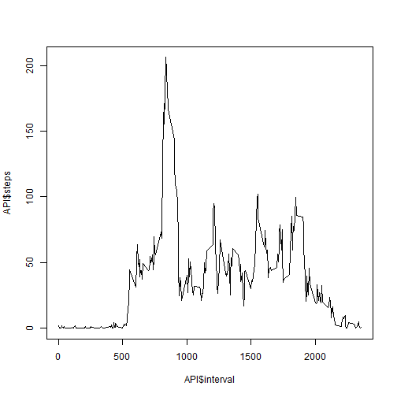

```r
plot(API$interval, API$steps, type = "l")
```

Visually, it's easy to see the “spike” in steps.

But if someone asked you, “Which specific interval averages the most steps?”

We'd have to calculate that…

```r
MaxInterval <- API[which(API$steps == max(API$steps)),]
MaxInterval
```

```
##     interval    steps     date
## 104      835 206.1698 30.71698
```

OK, so Interval #835 is the winner, with 206.2 steps on average.

Now, let's move on to something altogether different.

There seem to be some missing values (i.e. “NA"s) in our dataset. See…

```r
head(df)
```

```
##   steps       date interval
## 1    NA 2012-10-01        0
## 2    NA 2012-10-01        5
## 3    NA 2012-10-01       10
## 4    NA 2012-10-01       15
## 5    NA 2012-10-01       20
## 6    NA 2012-10-01       25
```

Let's address those missing values.

First, let's figure out how many rows within our dataset contain at least one missing value (i.e. "NA”).

```r
TotalNAs <- sum(is.na(df))
TotalNAs
```

```
## [1] 2304
```

Wow, 2304 missing values… that's a lot.

Let's now devise a simple strategy for replacing those missing values. There are many ways to do this.

I'll choose this one: replace any NA value with the value equal to the average value of the interval in question.

```r
df_new <- df

df_new$steps <- ifelse(is.na(df_new$steps) == TRUE, API$steps[API$interval %in% df_new$interval], df_new$steps)
```

Let's see if that worked…

```r
head(df_new)
```

```
##       steps       date interval
## 1 1.7169811 2012-10-01        0
## 2 0.3396226 2012-10-01        5
## 3 0.1320755 2012-10-01       10
## 4 0.1509434 2012-10-01       15
## 5 0.0754717 2012-10-01       20
## 6 2.0943396 2012-10-01       25
```

```r
tail(df_new)
```

```
##           steps       date interval
## 17563 2.6037736 2012-11-30     2330
## 17564 4.6981132 2012-11-30     2335
## 17565 3.3018868 2012-11-30     2340
## 17566 0.6415094 2012-11-30     2345
## 17567 0.2264151 2012-11-30     2350
## 17568 1.0754717 2012-11-30     2355
```

```r
sum(is.na(df_new))
```

```
## [1] 0
```

Looks good to me!

Now, let's make a histogram of the new dataframe, which is equivalent to the original dataframe, only with all the NAs replaced.

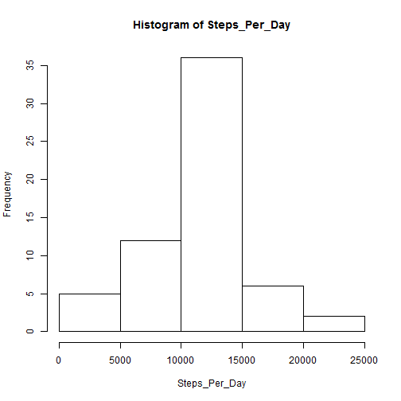

```r
TotalPerDay <- aggregate(. ~ date, data=df_new, sum)

Steps_Per_Day <- TotalPerDay$steps
hist(Steps_Per_Day)
```

Visually, that histogram looks just like the original histogram of Total Steps Per Day, which had missing NAs value.

But let's be more precise. Calculating the mean and median of our new dataset, with NAs replaced, will help.

```r
new_mean <- mean(Steps_Per_Day)
new_median <- median(Steps_Per_Day)

new_mean
```

```
## [1] 10766.19
```

```r
new_median
```

```
## [1] 10766.19
```

Compared to the “original” values:

```r
steps_mean
```

```
## [1] 10766.19
```

```r
steps_median
```

```
## [1] 10765
```

The mean has not changed at all. And the median has changed only ever so slightly (basically, it hasn't changed).

Sadly, it seems our replacement of the NAs had no effect… it was a waste of time (except I'm learning R!)

Now, let's explore one last thing.

I wonder if people take more steps on Weekdays versus Weekend Days.

First, we have to create a new variable - one that defines the date variable as either: “Weekday” or “Weekend”. That sounds like a “factor” variable with two levels.

We'll start this work on our “NA-replaced” dataset (i.e. df_new)

```r
df_new$date <- as.Date(df_new$date)

weekdays1 <- c('Monday', 'Tuesday', 'Wednesday', 'Thursday', 'Friday')

df_new$wDay <- factor((weekdays(df_new$date) %in% weekdays1), levels = c(FALSE,TRUE), labels=c('Weekend','Weekday'))
```

Let's make sure our new variable is a “factor” variable:

```r
class(df_new$wDay)
```

```
## [1] "factor"
```

And glance at the head of our new dataset:

```r
head(df_new)
```

```
##       steps       date interval    wDay
## 1 1.7169811 2012-10-01        0 Weekday
## 2 0.3396226 2012-10-01        5 Weekday
## 3 0.1320755 2012-10-01       10 Weekday
## 4 0.1509434 2012-10-01       15 Weekday
## 5 0.0754717 2012-10-01       20 Weekday
## 6 2.0943396 2012-10-01       25 Weekday
```

Good, all looks well!

Next, let's subset this dataset based on our Weekday/Weekend factor variable:

```r
weekend_set <- subset(df_new, wDay == "Weekend")

weekday_set <- subset(df_new, wDay == "Weekday")
```

Now we can compute the Average Steps per Interval, for each subset:

```r
API_weekend <- aggregate(. ~ interval, data = weekend_set, mean)
API_weekend$wDay <- factor("Weekend")

API_weekday <- aggregate(. ~ interval, data = weekday_set, mean)
API_weekday$wDay <- factor("Weekday")
```

Let's recombine those subsets, to make a Panel Plot easier.

```r
new_API <- rbind(API_weekend,API_weekday)
```

And, finally, make a Panel plot… comparing the diference in Average Steps per Interval for Weekdays versus Weekends:

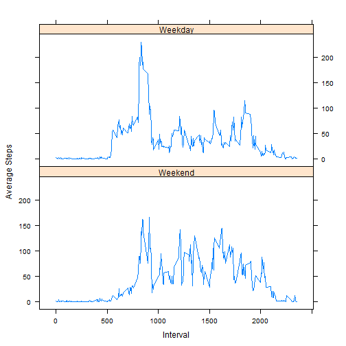

```r
library(lattice)
xyplot(steps ~ interval | wDay,
        data = new_API,
        type = "l",
        xlab = "Interval",
        ylab = "Average Steps",
        layout = c(1,2))
```

Interesting!

It seems that on Weekdays, more steps are taken between the 500 and 1000 intervals.

But on Weekends, more steps are taken between the 1000 and 2000 intervals.

Although, overall, the patterns of activity are very similar on both Weekdays and Weekends.

This was a fun investigation of data!

See you next time…